# RRV Project

# **Purpose**

There are many research projects conducted on vastly different organisms that are not related to virus research. Because the focus on a given research task does not involve the detection or discovery of viruses, this is often overlooked and provides an opportunity for virologists to comb through the data and see if viruses are present. Given that each organism present on plant Earth is estimated to be infected by at least one virus, this provides ample opportunity to discover novel viruses in a host of interest.

Not only is this conceptual, but this as been applied in a variety of hosts. I will focus on viruses isolated from roses in this case.

In roses,

Xing, F., Gao, D., Habili, N., Wang, H., Zhang, Z., Cao, M., & Li, S. (2021). Identification and molecular characterization of a novel carlavirus infecting rose plants (Rosa chinensis Jacq.). Archives of Virology, 166, 3499-3502.

- RVC was found by looking through transcriptome data
- This can help in the future as growers and diagnosticians decide which viruses they should screen for.

# **Exploring RNA-seq data for the presence of unreported or novel viruses in the genus *Rosa***

## **Overview of the project**

1. Download SRA data (RNA-seq) -> using the array system
2. Download Reference genome
3. QC and trimming of raw data
4. Reference mapping of reads to host genome(Hisat2 which is best used for RNA onto DNA: think about exons)
5. Gather unmapped reads using the flags (may have to convert the SAM to a fastq file for assembly)
6. Assembly of reads (rnaSPADES)
7. Create a database of viruses (using the taxa accession or ID) so that BLAST can be run locally
8. Use Diamond for blasting (requires protein sequences: translate the nucleic acid to protein)
9. Accumulate BLAST results for both nucleotide and protein blast
10. Analyze results

> I am planning to maintain everything in the scratch folder on the OSCER. Also, I am keeping all the scripts in my Rstudio folder so that I can easily upload the correct scripts while correcting them when submitting jobs.

### **1. Download SRA Data (RNA-Seq)**

1. Login to OSCER

```
ssh [YOUR_ACCOUNT_ID]@schooner.oscer.ou.edu
```

2. Activate environment

```
mamba activate /home/mbtoomey/.conda/envs/BIOL7263_Genomics
```

3. Submit a job to OSCER

```
sbatch /scratch/biol726310/BIOL7263_Genomics/rrv_project/scripts/[file_name.sbatch]
```

4. Check on a job

```
squeue -u biol726310
```

5. We can include this line of code in our script.

```
module load SRA-Toolkit/3.0.3-gompi-2022a
```

6. The following code is our `.sbatch` file and contains the `array` argument. This must be altered according to the number of individual jobs being submitted.

Below are the files submitted to OSCER:

1. **sbatch file**
2. **sh script**
3. **.args**
7. Here is our `.sh` script file which contains a line of code that specifies a loading of the SRA-Toolkit. This program will be used to obtain data associated with a specific accessions.
8. Lastly, we have a `.args` file which contains a list of information that will be run using the array system.

In this case, we set the array argument to `1-3`. This means, the array will only process the first three arguments in the `.args` file.

*___________________________________________________________________________________________________*

### **2. Downloading the Reference genome of interest**

In this case, we will use the *Rosa chinensis* genome as a reference. This reference corresponds with the RNA-seq data downloaded in the previous section.

We can manually download the data of interest, or download using the `wget` command and the respective link. Below is from our class exercises.

Steps: 1. Go to NCBI 2. Go the genomes 3. Search organism of interest 4. Select FTP 5. Copy link for file of interest (in our case, we will copy the link for the genomic.fna.gz, we may also want to grab the genomic.gff.gz)

1. **sh script**
2. **sbatch file**

Once these are downloaded, we will likely need to unzip them for further analysis. In this case, we will use an `gunzip` command, which we have incorporated into the above script.

### **3. QC and trimming of raw data**

As part of the analysis, it is important to consider the quality of the reads being analyzed. This is publicly available data, therefore, I assume the data is of high quality (otherwise, why publish?). Either way, we will still work through the process of data quality control and trimming of the raw fastq files (for sake of practice and understanding).

To view the first few headers we can use the `zcat` command (this is similar to ‘cat’ but works with zipped files). We can also use `head` and `tail` to look at the data. So in the case that our file is NOT zipped, we will use `cat`, otherwise we will use `zcat`.

```
cat /scratch/biol726310/BIOL7263_Genomics/rrv_project/SRR29872023_1.fastq | head | grep @SRR
cat /scratch/biol726310/BIOL7263_Genomics/rrv_project/SRR29872023_2.fastq | head | grep @SRR
```

Check that there is an identical number of reads in each file (this one is not working):

```
cat /scratch/biol726310/BIOL7263_Genomics/rrv_project/SRR29872023_2.fastq | grep @SRR | wc –l
```

From our class exercises: We will need to create `.sh` and `.sbatch` files with our code. Generally anything with a median quality score greater than Q20 is regarded as acceptable; anything above Q30 is regarded as ‘good’.

Below are the files submitted to OSCER:

1. **sbatch file**
2. **sh script**

Here we are only looking at one sample, which is `SRR29872023_1` and `SRR29872023_2`. If we wanted to use an array system, we could look at all of the files and have `fastqc` run for each of them.

> If I complete the main project, I will use an array at this step (likely other steps downstream) to process a larger number of samples.

#### **Results of the quality control using fastqc**

[interactive chart not shown]

### **Trimming**

We will create a new directory where we can store the trimmed data and simply call it `trimmed_data`.

```
mkdir /scratch/biol726310/BIOL7263_Genomics/rrv_project/trimmed_data
```

We will now create the script that we can use to initate the trimming program.

Below are the files submitted to OSCER:

1. **sh script**
2. **sbatch file**

[interactive chart not shown]

*___________________________________________________________________________________________________*

### **4. Reference mapping of reads to host genome**

Usually, we would use BWA (currently called `minimap2`) to map reads to a reference genome. We will be using Hisat2 for read mapping because this program is particular good at mapping RNA reads onto a DNA genome.

General steps: 1) Create a reference index of the reference sequence (host sequence in most of our cases)

2. Map raw, trimmed, de novo assembled (any reads) to the indexed reference sequence
3. The output will be a `.SAM` file (Simple Alignment format)
4. Convert the `.SAM` to a `.BAM` (Binary alignment format). `.SAM` files are great for readability but they do not do so well with computational accessibility. This is why we convert the file to `.BAM`.
5. Sort the `.BAM` file.

The below code is from Salil:

1. creating a new environment

```
conda create -n hisat2_env
```

2. activate the environment

```
conda activate hisat2_env
```

> `mamba` can also be used instead of `conda`
3. We will likely have to configure the channels that will be required for package installation.

```
conda config --add channels bioconda
conda config --add channels conda-forge
conda config --add channels defaults
```

4. We can check the channels with the following commands. The order is important

```
conda config --show channels
```

5. Install a program of interest (hisat2)

```
conda install hisat2
```

6. unzip the file of interest

```
gunzip [file of interest, usually *.gz]
```

7. create an index file

```
hisat2-build /scratch/biol726310/BIOL7263_Genomics/rrv_project/reference_genome/GCA_002994745.2_RchiOBHm-V2_genomic.fna /scratch/biol726310/BIOL7263_Genomics/rrv_project/reference_genome/indexed_genome
```

8. Aligning reads to the indexed reference genome

```
hisat2 -x /scratch/biol726310/BIOL7263_Genomics/rrv_project/reference_genome/indexed_genome -1 /scratch/biol726310/BIOL7263_Genomics/rrv_project/trimmed_data/trimmed_reads_val_1.fq.gz -2 /scratch/biol726310/BIOL7263_Genomics/rrv_project/trimmed_data/trimmed_reads_val_2.fq.gz -S /scratch/biol726310/BIOL7263_Genomics/rrv_project/hisat2.sam
```

Generic form of the command.

```
hisat2 -x indexed_genome -1 reads_1.fastq -2 reads_2.fastq -S output.sam
```

`-x index_basename`: The name of the genome index files (from the indexing step). `-1 reads_1.fastq`: The file containing the first reads of the paired-end data (these might have to be decompressed or `gunzipped`). `-2 reads_2.fastq`: The file containing the second reads of the paired-end data (these might have to be decompressed or `gunzipped`). `-S output.sam`: The name of the output file in SAM format. `--dta`: This option enables HISAT2 to output alignments tailored for transcript assembly with tools like StringTie. `--threads`: Specifies the number of threads to use for faster alignment:

Below I have included the script file for the `hisat2` mapping.

1. **sh script**
2. **sbatch file**

We will need to deactivate the current environment and activate the class environment to finish the remaining steps.

Activate environment

```
mamba deactivate
```

```
mamba activate /home/mbtoomey/.conda/envs/BIOL7263_Genomics
```

9. Convert the `.SAM` to `.BAM`

```
samtools view -S -b /scratch/biol726310/BIOL7263_Genomics/rrv_project/hisat2.sam > /scratch/biol726310/BIOL7263_Genomics/rrv_project/hisat2.bam
```

`-S`: Indicates that the input is in SAM format. `-b`: Specifies that the output should be in BAM format.

10. Sorting the `.BAM` file.

```
samtools sort /scratch/biol726310/BIOL7263_Genomics/rrv_project/hisat2.bam -o /scratch/biol726310/BIOL7263_Genomics/rrv_project/sorted_hisat2.bam
```

11. Indexing the `.BAM` file

Indexing the sorted BAM file allows fast access for viewing alignments or further processing (e.g., in tools like IGV or featureCounts).

```
samtools index /scratch/biol726310/BIOL7263_Genomics/rrv_project/sorted_hisat2.bam
```

12. We can check the alignment statistics using a few tools.

```
samtools flagstat /scratch/biol726310/BIOL7263_Genomics/rrv_project/sorted_hisat2.bam > /scratch/biol726310/BIOL7263_Genomics/rrv_project/mappingstats.txt
```

> This worked well (very fast also)!

```r
# Specify the path to your text file
file_path <- "data_output/mappingstats.txt"

# Read the text file
text_content <- readLines(file_path)

# Print the content of the text file
cat(head(text_content, 30), sep = "\n")
```

```
## 48805428 + 0 in total (QC-passed reads + QC-failed reads)
## 1532032 + 0 secondary
## 0 + 0 supplementary
## 0 + 0 duplicates
## 43288907 + 0 mapped (88.70% : N/A)
## 47273396 + 0 paired in sequencing
## 23636698 + 0 read1
## 23636698 + 0 read2
## 39080286 + 0 properly paired (82.67% : N/A)
## 39441476 + 0 with itself and mate mapped
## 2315399 + 0 singletons (4.90% : N/A)
## 171226 + 0 with mate mapped to a different chr
## 152303 + 0 with mate mapped to a different chr (mapQ>=5)
```

We can also use the qualimap program to check the alignment.

```
qualimap bamqc -outdir /scratch/biol726310/BIOL7263_Genomics/rrv_project/bamqc -bam /scratch/biol726310/BIOL7263_Genomics/rrv_project/sorted_hisat2.bam -gff /scratch/biol726310/BIOL7263_Genomics/rrv_project/reference_genome/GCA_002994745.2_RchiOBHm-V2_genomic.gff
```

> Works well (slow processing)

```r
# Specify the path to your text file
file_path <- "data_output/genome_results.txt"

# Read the text file
text_content <- readLines(file_path)

# Print the content of the text file
cat(head(text_content, 30), sep = "\n")
```

```
## BamQC report
## -----------------------------------
##
## >>>>>>> Input
##
##      bam file = /scratch/biol726310/BIOL7263_Genomics/rrv_project/sorted_hisat2.bam
##      outfile = /scratch/biol726310/BIOL7263_Genomics/rrv_project/bamqc/genome_results.txt
##
##
## >>>>>>> Reference
##
##      number of bases = 515,588,973 bp
##      number of contigs = 55
##
##
## >>>>>>> Globals
##
##      number of windows = 454
##
##      number of reads = 47,273,396
##      number of mapped reads = 41,756,875 (88.33%)
##      number of secondary alignments = 1,532,032
##
##      number of mapped paired reads (first in pair) = 20,965,602
##      number of mapped paired reads (second in pair) = 20,791,273
##      number of mapped paired reads (both in pair) = 39,441,476
##      number of mapped paired reads (singletons) = 2,315,399
##
##      number of mapped bases = 30,019,458,809 bp
##      number of sequenced bases = 6,217,039,734 bp
```

The following code has been added to a script file that contains all of the steps in one document. The comments need to be removed, but the code can be run multiple lines at a time (the only problem is the use of different environments, otherwise, we could run it all together).

1. **sh script**
2. **sbatch file**
- Because we are using two different environments, I will have to change environments after this step. (If I created an environment with all of the programs in one, I could easily use the same environment for all the anlayses).

```
mamba deactivate
```

```
mamba activate hisat2_env
```

Generic formula for the data input.

```
hisat2 -x genome_index -1 sample_1.fastq -2 sample_2.fastq -S alignment.sam --summary-file alignment_summary.txt
```

[output not shown]

> Works well (very slow processing)!

```r
# Specify the path to your text file
file_path <- "data_output/alignment_summary.txt"

# Read the text file
text_content <- readLines(file_path)

# Print the content of the text file
cat(head(text_content, 30), sep = "\n")
```

```
## 23636698 reads; of these:
##   23636698 (100.00%) were paired; of these:
##     4096555 (17.33%) aligned concordantly 0 times
##     19022555 (80.48%) aligned concordantly exactly 1 time
##     517588 (2.19%) aligned concordantly >1 times
##     ----
##     4096555 pairs aligned concordantly 0 times; of these:
##       70100 (1.71%) aligned discordantly 1 time
##     ----
##     4026455 pairs aligned 0 times concordantly or discordantly; of these:
##       8052910 mates make up the pairs; of these:
##         5516521 (68.50%) aligned 0 times
##         2441427 (30.32%) aligned exactly 1 time
##         94962 (1.18%) aligned >1 times
## 88.33% overall alignment rate
```

Below I have included the files for OSCER submission. The `hisat2` version for checking the alignment works very similar to the `qualimap` alignment check.

1. **sh script**
2. **sbatch file**

*___________________________________________________________________________________________________*

### **5. Gather unmapped reads using the flags**

We will start by creating a new directory to store the unmapped reads.

```
mkdir unmapped
```

We need to first extract the unmapped reads from the file

```
samtools view -b -f 12 /scratch/biol726310/BIOL7263_Genomics/rrv_project/sorted_hisat2.bam -o /scratch/biol726310/BIOL7263_Genomics/rrv_project/unmapped.bam
```

> Apparently, according to other sources, the `-f` argument should be `4` instead of `12` when considering an unpaired read. The argument `12` is used to obtain unmapped reads from both pairs.

We will need to then convert the unmapped reads back to a fastq format so that the SPAdes assembler can read the input file. We can convert `.BAM` to fastq using bedtools or samtools.

```
bedtools bamtofastq -i /scratch/biol726310/BIOL7263_Genomics/rrv_project/unmapped.bam -fq /scratch/biol726310/BIOL7263_Genomics/rrv_project/unmapped/unmapped_r1.fastq -fq2 /scratch/biol726310/BIOL7263_Genomics/rrv_project/unmapped/unmapped_r2.fastq
```

> This worked very well.

```
# Convert the .BAM file to a format (using samtools) that can be read by SPAdes such as fastq
samtools fastq /scratch/biol726310/BIOL7263_Genomics/rrv_project/unmapped/unmapped.bam -1 /scratch/biol726310/BIOL7263_Genomics/rrv_project/unmapped/output_1.fastq -2 /scratch/biol726310/BIOL7263_Genomics/rrv_project/unmapped/output_2.fastq
```

> This worked very well.

I was able to use both tools (bedtools and samtools) to generate fastq files. Below are the documents submitted to OSCER:

1. **sh script**
2. **sbatch file**

*___________________________________________________________________________________________________*

### **6. Assembly of unmapped reads (rnaSPADES)**

First we will make a directory to contain our assembly data.

```
mkdir assembly
```

```
spades.py --rna --threads 24 -o /scratch/biol726310/BIOL7263_Genomics/rrv_project/assembly/spades_assembly -1 /scratch/biol726310/BIOL7263_Genomics/rrv_project/unmapped/output_1.fastq -2 /scratch/biol726310/BIOL7263_Genomics/rrv_project/unmapped/output_2.fastq
```

Apparently, we can process multiple fastq files in one assembly step. This may be useful down to the road. Otherwise, we may use the array system.

```
spades.py --rna --threads 24 -o output_directory -1 reads_1_1.fastq.gz -2 reads_1_2.fastq.gz -1 reads_2_1.fastq.gz -2 reads_2_2.fastq.gz
```

Check how the assembly went using QUAST.

```
quast.py --output-dir /scratch/biol726310/BIOL7263_Genomics/rrv_project/assembly/spades_assembly/quast /scratch/biol726310/BIOL7263_Genomics/rrv_project/assembly/spades_assembly/transcripts.fasta
```

```r
# Specify the path to your text file
file_path <- "data_output/quast_report.txt"

# Read the text file
text_content <- readLines(file_path)

# Print the content of the text file
cat(head(text_content, 30), sep = "\n")
```

```
## All statistics are based on contigs of size >= 500 bp, unless otherwise noted (e.g., "# contigs (>= 0 bp)" and "Total length (>= 0 bp)" include all contigs).
##
## Assembly                    transcripts
## # contigs (>= 0 bp)         51321
## # contigs (>= 1000 bp)      3542
## # contigs (>= 5000 bp)      39
## # contigs (>= 10000 bp)     0
## # contigs (>= 25000 bp)     0
## # contigs (>= 50000 bp)     0
## Total length (>= 0 bp)      23962415
## Total length (>= 1000 bp)   6046849
## Total length (>= 5000 bp)   226142
## Total length (>= 10000 bp)  0
## Total length (>= 25000 bp)  0
## Total length (>= 50000 bp)  0
## # contigs                   11871
## Largest contig              7867
## Total length                11673416
## GC (%)                      40.75
## N50                         1035
## N75                         687
## L50                         3336
## L75                         6846
## # N's per 100 kbp           36.15
```

1. **sh script**
2. **sbatch file**

*___________________________________________________________________________________________________*

### **7. Create a database of viruses (using the taxa accession or ID) so that BLAST can be run locally**

#### Nucleotide BLAST

To search a nucleotide database we can use the blast+ suite of tools. This is the exact same tool that is used for online blast searches. However, when we implement it on our system we will need to provide a search database. The blast+ suit includes a script to download the preconfigured databases from NCBI: [BLAST](https://www.ncbi.nlm.nih.gov/books/NBK569850/)

We will likely have to navigate to the directory where we plan to create the databases.

To check the databases that are available you can run:

```
update_blastdb.pl --showall
```

```
update_blastdb.pl --decompress [DATABASE NAME]
```

```
update_blastdb.pl --decompress nt_viruses
```

It may be required to unzip the previous file.

```
tar -xvzf nt_viruses.00.tar.gz
```

*core_nt* is the default database used in online blast searches, but is >160Gb. This is not feasible for our searches. We can download the *nt_viruses* or *nt_prok* databases, which are much smaller in relative size. The *nt_euk* is very much impractically large.

We can create a smaller database that contains certain viruses to reduce the search time. We also may be interested in fungi, bacteria, phytoplasma, etc.

Rather than relying on the above process (which were difficult to integrate), I simply downloaded nucleotide sequences manually for all viruses using NCBI.

```
makeblastdb -in human_RNA.fna -parse_seqids -blastdb_version 5 -title "Human RNA" -dbtype nucl -out human_rna_db
```

Now that we have generated the nucleotide database, we can use the `blastn` command to search the database for homologous sequences.

```
blastn -db /scratch/biol726310/BIOL7263_Genomics/rrv_project/databases/virus_db -query transcripts.fasta -outfmt "6 qseqid sseqid stitle" -num_threads 20 -num_alignments 1 > TTC_rna_blast.tsv
```

In the following code, I have written it in such a way as to generate a csv file that can be analyzed easily.

```
blastn -query /scratch/biol726310/BIOL7263_Genomics/rrv_project/assembly/spades_assembly/transcripts.fasta -db /scratch/biol726310/BIOL7263_Genomics/rrv_project/databases/virus_db/nt_viruses -out /scratch/biol726310/BIOL7263_Genomics/rrv_project/blasting/nt_results.csv -evalue 1e-5 -max_target_seqs 5 -num_threads 20 -outfmt "10 qseqid stitle pident length mismatch gapopen qstart qend sstart send evalue bitscore"
```

`qseqid`: Query sequence ID. `sseqid`: Subject (database) sequence ID. `pident`: Percentage of identical matches. `length`: Alignment length of nucleotides OR amino acid residues `mismatch`: Number of mismatches. `gapopen`: Number of gap openings. `qstart`: Start of alignment in the query. `qend`: End of alignment in the query. `sstart`: Start of alignment in the subject (database). `send`: End of alignment in the subject. `evalue`: Expect value (E-value). `bitscore`: Bit score.

Below I have included my files for OSCER submission:

1. **.sh script**
2. **.sbatch file**

*___________________________________________________________________________________________________*

### **8. Use Diamond for blasting against protein sequences (like BLASTx)**

We will use Diamond to run efficient blast searches of databases. Similar to the nucleotide database, we are going to build our own database for this search. To do this lets go to the Uniprotkb database and download all of the protein sequences for our organisms of interest.

We can download the sequences as `.fasta` files to construct our database. We can download from uniprotkb or NCBI.

Here is the taxon ID for viruses 10239. I was able to generate a link from the Uniprotkb website that will download all of the protein sequences using the link (rather than downloading manually).

Below I have included my files for OSCER submission:

1. **.sh script**
2. **.sbatch file**

This is how we can join two databases (more than one organism of interest). We can join the data set, and then create the database using the below code.

```
cat ZeFi_proteins.fasta chicken_proteins.fasta > bird_proteins.fasta
```

Here is the command for building the database. This step is critical as it will generate the `.dmnd` formatted file.

```
diamond makedb --in /scratch/biol726310/BIOL7263_Genomics/rrv_project/databases/protein_db/all_virus_protein -d /scratch/biol726310/BIOL7263_Genomics/rrv_project/databases/protein_db/virus_protein_db
```

`-d` sets the path to our database. `-k` limits the output to the top hit only. `-q` sets the path to our query sequences from the genome `-o` sets the name of the output file `--threads` sets the number of cpu cores to use for the anlysis. Remember to match this in the .sbatch file. `--outfmt 6` sets the output to a table.

Now we can run the blast search, however this time we will be searching RNA transcripts against a protein database. Therefore, we will use the blastx search option in diamond. The following code is supposed to generate a `.csv` file type that will be much easier to analyze and can be quickly summarized.

```
diamond blastx -d /scratch/biol726310/BIOL7263_Genomics/rrv_project/databases/protein_db/virus_protein_db.dmnd -q /scratch/biol726310/BIOL7263_Genomics/rrv_project/assembly/spades_assembly/transcripts.fasta --outfmt 6 qseqid stitle pident length mismatch gapopen qstart qend sstart send evalue bitscore --max-target-seqs 5 --threads 20 | sed 's/\t/,/g' > /scratch/biol726310/BIOL7263_Genomics/rrv_project/blasting/diamond_results.csv
```

Below I have included my files for OSCER submission:

> These files include both nucleotide and diamond blast searches on the same file. This makes it easier to simply run one job and get both results as output.
1. **.sh script**
2. **.sbatch file**

*___________________________________________________________________________________________________*

### **9. Analyze BLAST and Diamond results for both nucleotide and amino acid sequences**

- I was able to generate a `.csv` output so that I can quickly evaluate the data generated using R. The goal is to easily render a document that summarizes our findings.
- Using R, we manipulated the input `.csv` file to make it more user friendly, and to include important sequencing results.

```r
protein_df <- read.csv("data_output/diamond_results.csv", header = FALSE)

colnames(protein_df) <- c("Query_ID","Seq_Title", "Percent_ID", "Align_Length", "Mismatch", "Gap_Open", "Query_Start", "Query_End", "Seq_Start","Send", "Evalue", "bitscore")


df_split <- protein_df %>%
  mutate(NODE = str_extract(Query_ID,"NODE_[0-9]+"),
         LENGTH =
str_extract(Query_ID, "length_[0-9]+"),
         COV =
str_extract(Query_ID, "cov_[0-9]+\\.[0-9]+"))


df_cleaned <- df_split %>%
  mutate(
    NODE = gsub("NODE_", "", NODE),      # Remove NODE_ prefix
    LENGTH = gsub("length_", "", LENGTH), # Remove length_ prefix
    COV = gsub("cov_", "", COV))           # Remove cov_ prefix


## Cleaning up the sequence title by extracting the OS portion
df_cleaned <- df_cleaned %>%
  mutate(Seq_Title_Org = str_extract(Seq_Title, "OS=([^O]+)"))


df_complete <- df_cleaned %>%
  select("Seq_Title_Org","NODE","LENGTH","COV","Percent_ID","Align_Length","Mismatch","Gap_Open","Evalue")

## Changing the variable type of one variable
df_complete$NODE <- as.numeric(df_complete$NODE)
df_complete$LENGTH <- as.numeric(df_complete$LENGTH)
df_complete$COV <- as.numeric(df_complete$COV)
df_complete$Percent_ID <- as.numeric(df_complete$Percent_ID)
df_complete$Align_Length <- as.numeric(df_complete$Align_Length)
df_complete$Mismatch <- as.numeric(df_complete$Mismatch)
df_complete$Gap_Open <- as.numeric(df_complete$Gap_Open)
summary(df_complete)
```

```
##  Seq_Title_Org           NODE           LENGTH            COV
##  Length:8722        Min.   :    9   Min.   : 196.0   Min.   :  0.717
##  Class :character   1st Qu.: 8064   1st Qu.: 268.0   1st Qu.:  1.757
##  Mode  :character   Median :24939   Median : 329.0   Median :  2.942
##                     Mean   :23987   Mean   : 611.2   Mean   :  8.483
##                     3rd Qu.:37773   3rd Qu.: 627.0   3rd Qu.:  6.079
##                     Max.   :51281   Max.   :6217.0   Max.   :435.111
##                     NA's   :208     NA's   :208      NA's   :208
##    Percent_ID      Align_Length       Mismatch         Gap_Open
##  Min.   :  0.00   Min.   :  2.00   Min.   :  0.00   Min.   :  0.000
##  1st Qu.: 38.80   1st Qu.: 62.00   1st Qu.: 27.00   1st Qu.:  0.000
##  Median : 47.30   Median : 82.00   Median : 40.00   Median :  1.000
##  Mean   : 49.53   Mean   : 99.25   Mean   : 50.62   Mean   :  2.662
##  3rd Qu.: 57.30   3rd Qu.:107.00   3rd Qu.: 57.00   3rd Qu.:  2.000
##  Max.   :100.00   Max.   :861.00   Max.   :497.00   Max.   :159.000
##  NA's   :410      NA's   :214      NA's   :211      NA's   :211
##      Evalue
##  Min.   :   0.000
##  1st Qu.:   0.000
##  Median :   0.000
##  Mean   :   8.733
##  3rd Qu.:   0.000
##  Max.   :1707.000
##  NA's   :208
```

> Now that we can look at the data obtained from the search and summarize it. We can look at a couple of parameters such as the coverage, percent ID, length, mismatch, etc.

```r
head(df_complete %>% arrange(desc(LENGTH)),10)
```

[output not shown]

```r
head(df_complete %>% arrange(desc(COV)),10)
```

```
##                           Seq_Title_Org NODE LENGTH      COV Percent_ID
## 1                    OS=Hokovirus HKV1  1770   1418 435.1115       93.3
## 2     OS=Bovine viral diarrhea virus 2  1770   1418 435.1115       83.1
## 3     OS=Bovine viral diarrhea virus 2  1770   1418 435.1115       91.9
## 4       OS=Bovine viral diarrhea virus  1770   1418 435.1115       91.5
## 5     OS=Bovine viral diarrhea virus 2  1770   1418 435.1115       92.0
## 6  OS=Megaviridae environmental sample  1679   1450 382.6333       54.5
## 7       OS=Dishui lake phycodnavirus 1  3664    977 314.6836       86.8
## 8                    OS=Sylvanvirus sp  3664    977 314.6836       72.5
## 9           OS=Manila clam xenomavirus  3664    977 314.6836       57.0
## 10          OS=Marseillevirus LCMAC102  3664    977 314.6836       53.0
##    Align_Length Mismatch Gap_Open    Evalue
## 1           225       15        0 2.32e-139
## 2           213       29        1 1.36e-107
## 3           173       14        0 4.91e-100
## 4           177       15        0  6.61e-95
## 5           163       13        0  5.02e-92
## 6            44       20        0  1.14e-04
## 7           136       18        0  8.09e-72
## 8           138       36        1  6.58e-58
## 9           149       50        3  3.66e-39
## 10          117       51        2  1.10e-24
```

```r
head(df_complete %>% arrange(desc(Percent_ID)),10)
```

```
##                Seq_Title_Org  NODE LENGTH        COV Percent_ID Align_Length
## 1      OS=Rose partitivirus   1222   1687  29.425031        100          487
## 2   OS=Rose cryptic virus 1   1952   1351  81.942097        100          348
## 3   OS=Rose cryptic virus 1   2018   1336 133.779097        100          346
## 4   OS=Rose cryptic virus 1   2785   1138  10.477934        100          340
## 5  OS=Escherichia phage TR2  13394    466   2.633588        100           46
## 6   OS=Rose cryptic virus 1  15249    432   8.384401        100          130
## 7   OS=Rose cryptic virus 1  15249    432   8.384401        100          130
## 8   OS=Rose cryptic virus 1  15249    432   8.384401        100          130
## 9      OS=Rose partitivirus  18543    388   3.387302        100          129
## 10     OS=Rose partitivirus  18607    387   4.152866        100          128
##    Mismatch Gap_Open    Evalue
## 1         0        0  0.00e+00
## 2         0        0 3.28e-253
## 3         0        0 1.11e-256
## 4         0        0 6.04e-251
## 5         0        0  2.61e-25
## 6         0        0  6.89e-91
## 7         0        0  1.63e-87
## 8         0        0  1.63e-87
## 9         0        0  7.81e-89
## 10        0        0  3.54e-83
```

```r
head(df_complete %>% arrange(desc(Align_Length)),10)
```

```
##                              Seq_Title_Org NODE LENGTH       COV Percent_ID
## 1                     OS=Hyperionvirus sp   240   3075 37.511326       32.6
## 2                    OS=Terrestrivirus sp   240   3075 37.511326       29.9
## 3  OS=Peptoclostridium phage phiCDIF1296T   364   2718  6.899811       46.7
## 4              OS=Siphoviridae sp. ctBLh2   364   2718  6.899811       54.0
## 5  OS=Peptoclostridium phage phiCDIF1296T   364   2718  6.899811       54.5
## 6         OS=Acinetobacter phage MD-2021a   364   2718  6.899811       53.6
## 7             OS=Campylobacter phage PC10   364   2718  6.899811       49.4
## 8              OS=Atrato Retro-like virus    99   3893  4.802880       29.6
## 9              OS=Atrato Retro-like virus    99   3893  4.802880       29.9
## 10                      OS=Harvfovirus sp   240   3075 37.511326       36.6
##    Align_Length Mismatch Gap_Open    Evalue
## 1           861      462       23 4.39e-122
## 2           855      497       24 4.23e-104
## 3           715      297       11 2.83e-198
## 4           709      301        5 2.77e-249
## 5           705      314        3 6.63e-256
## 6           696      315        5 8.48e-250
## 7           696      340        5 9.70e-217
## 8           615      379       17  3.08e-64
## 9           615      377       17  2.89e-63
## 10          576      281       14 1.79e-106
```

```r
head(df_complete %>% arrange(Mismatch),10)
```

```
##                Seq_Title_Org  NODE LENGTH        COV Percent_ID Align_Length
## 1      OS=Rose partitivirus   1222   1687  29.425031        100          487
## 2   OS=Rose cryptic virus 1   1952   1351  81.942097        100          348
## 3   OS=Rose cryptic virus 1   2018   1336 133.779097        100          346
## 4   OS=Rose cryptic virus 1   2785   1138  10.477934        100          340
## 5  OS=Escherichia phage TR2  13394    466   2.633588        100           46
## 6   OS=Rose cryptic virus 1  15249    432   8.384401        100          130
## 7   OS=Rose cryptic virus 1  15249    432   8.384401        100          130
## 8   OS=Rose cryptic virus 1  15249    432   8.384401        100          130
## 9      OS=Rose partitivirus  18543    388   3.387302        100          129
## 10     OS=Rose partitivirus  18607    387   4.152866        100          128
##    Mismatch Gap_Open    Evalue
## 1         0        0  0.00e+00
## 2         0        0 3.28e-253
## 3         0        0 1.11e-256
## 4         0        0 6.04e-251
## 5         0        0  2.61e-25
## 6         0        0  6.89e-91
## 7         0        0  1.63e-87
## 8         0        0  1.63e-87
## 9         0        0  7.81e-89
## 10        0        0  3.54e-83
```

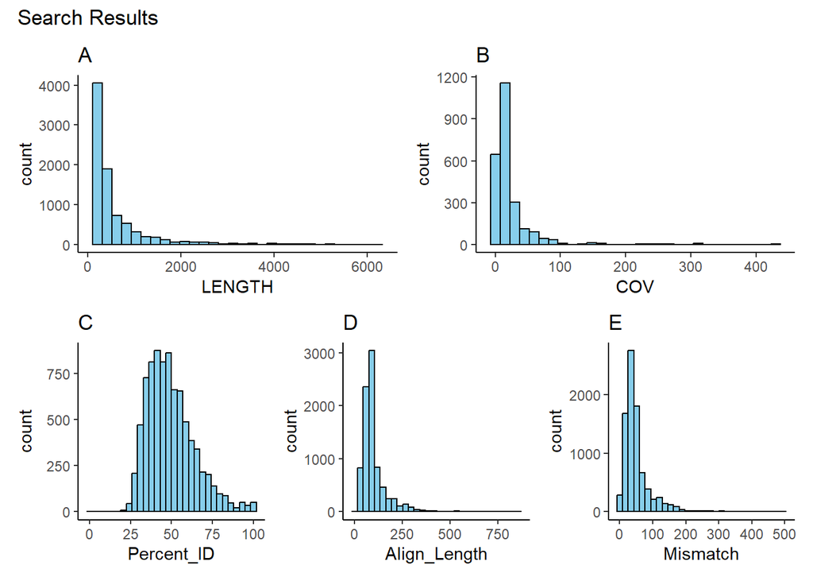

```r
plot_1 <- df_complete %>%
  ggplot(aes(x = LENGTH))+
  geom_histogram(fill = "skyblue", color = "black")+
  theme_classic()+
  ggtitle("A")

plot_2 <- df_complete %>% filter(COV >= 5) %>%
  ggplot(aes(x = COV))+
  geom_histogram(fill = "skyblue", color = "black")+
  theme_classic()+
  ggtitle("B")

plot_3 <- df_complete %>% ggplot(aes(x = Percent_ID))+
  geom_histogram(fill = "skyblue", color = "black")+
  theme_classic()+
  ggtitle("C")

plot_4 <- df_complete %>% ggplot(aes(x = Align_Length))+
  geom_histogram(fill = "skyblue", color = "black")+
  theme_classic()+
  ggtitle("D")

plot_5 <- df_complete %>% ggplot(aes(x = Mismatch))+
  geom_histogram(fill = "skyblue", color = "black")+
  theme_classic()+
  ggtitle("E")

(plot_1 | plot_2) / (plot_3 | plot_4 | plot_5) + plot_annotation("Search Results") # "|" arranges side-by-side, "/" arranges on top of each other
```

We can filter by a specific observations. This is a very useful tool, as we can obtain all of the nodes (contigs) that correspond to a given virus or other organism.

```r
df_complete %>% filter(Seq_Title_Org == "OS=Rose partitivirus ") ## Because of the manipulations
```

```
##           Seq_Title_Org  NODE LENGTH       COV Percent_ID Align_Length Mismatch
## 1 OS=Rose partitivirus   1222   1687 29.425031      100.0          487        0
## 2 OS=Rose partitivirus  18543    388  3.387302      100.0          129        0
## 3 OS=Rose partitivirus  18607    387  4.152866      100.0          128        0
## 4 OS=Rose partitivirus  29377    300  2.709251      100.0           85        0
## 5 OS=Rose partitivirus  37931    267  3.876289       97.7           88        2
## 6 OS=Rose partitivirus  43976    249  1.750000      100.0           60        0
##   Gap_Open   Evalue
## 1        0 0.00e+00
## 2        0 7.81e-89
## 3        0 3.54e-83
## 4        0 1.77e-55
## 5        0 6.27e-54
## 6        0 7.87e-37
```

```r
df_complete %>% filter(Seq_Title_Org == "OS=Rose cryptic virus 1 ") ## Because of the manipulations
```

```
##               Seq_Title_Org  NODE LENGTH        COV Percent_ID Align_Length
## 1  OS=Rose cryptic virus 1   1952   1351  81.942097      100.0          348
## 2  OS=Rose cryptic virus 1   1952   1351  81.942097       99.4          348
## 3  OS=Rose cryptic virus 1   1952   1351  81.942097       99.7          304
## 4  OS=Rose cryptic virus 1   1952   1351  81.942097       99.5          203
## 5  OS=Rose cryptic virus 1   2018   1336 133.779097      100.0          346
## 6  OS=Rose cryptic virus 1   2018   1336 133.779097       99.1          212
## 7  OS=Rose cryptic virus 1   2785   1138  10.477934      100.0          340
## 8  OS=Rose cryptic virus 1   2785   1138  10.477934       99.7          340
## 9  OS=Rose cryptic virus 1   2785   1138  10.477934       98.2          282
## 10 OS=Rose cryptic virus 1  15249    432   8.384401      100.0          130
## 11 OS=Rose cryptic virus 1  15249    432   8.384401      100.0          130
## 12 OS=Rose cryptic virus 1  15249    432   8.384401      100.0          130
##    Mismatch Gap_Open    Evalue
## 1         0        0 3.28e-253
## 2         2        0 3.82e-252
## 3         1        0 1.41e-218
## 4         1        0 9.08e-145
## 5         0        0 1.11e-256
## 6         2        0 6.04e-144
## 7         0        0 6.04e-251
## 8         1        0 3.49e-250
## 9         5        0 4.36e-203
## 10        0        0  6.89e-91
## 11        0        0  1.63e-87
## 12        0        0  1.63e-87
```

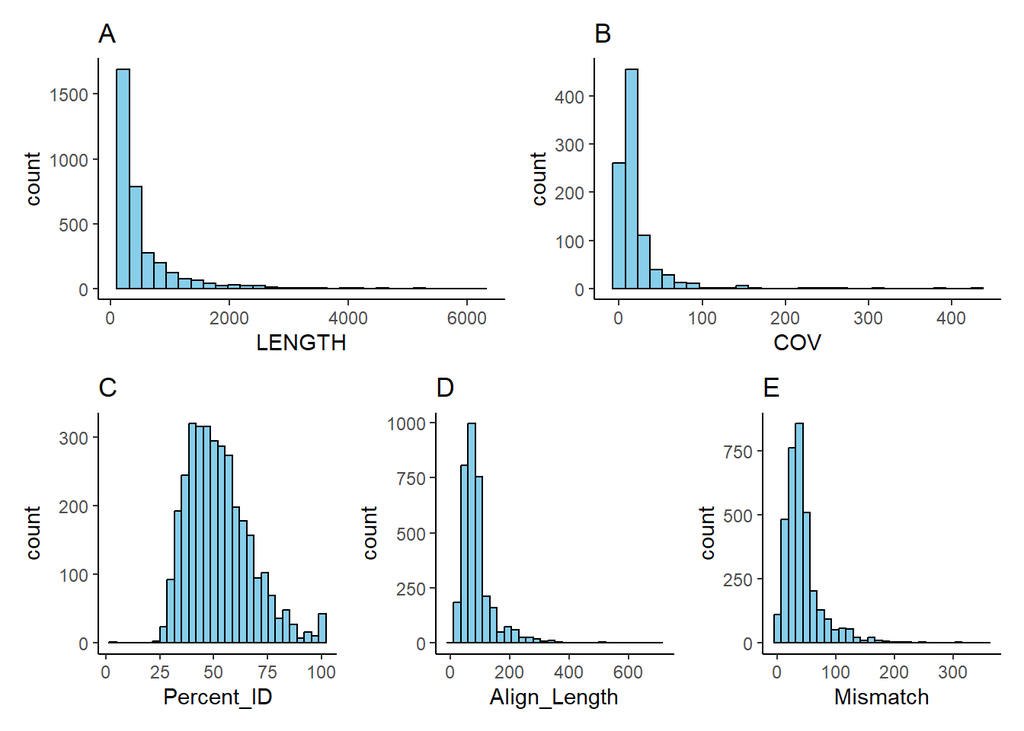

```r
reduced_data <- df_complete %>%
    group_by(NODE) %>%
    slice_max(Percent_ID, n = 1, with_ties = TRUE) %>%
    ungroup()  # Remove the grouping structure

plot_1 <- reduced_data %>%
  ggplot(aes(x = LENGTH))+
  geom_histogram(fill = "skyblue", color = "black")+
  theme_classic()+
  ggtitle("A")

plot_2 <- reduced_data %>% filter(COV >= 5) %>%
  ggplot(aes(x = COV))+
  geom_histogram(fill = "skyblue", color = "black")+
  theme_classic()+
  ggtitle("B")

plot_3 <- reduced_data %>% ggplot(aes(x = Percent_ID))+
  geom_histogram(fill = "skyblue", color = "black")+
  theme_classic()+
  ggtitle("C")

plot_4 <- reduced_data %>% ggplot(aes(x = Align_Length))+
  geom_histogram(fill = "skyblue", color = "black")+
  theme_classic()+
  ggtitle("D")

plot_5 <- reduced_data %>% ggplot(aes(x = Mismatch))+
  geom_histogram(fill = "skyblue", color = "black")+
  theme_classic()+
  ggtitle("E")

(plot_1 | plot_2) / (plot_3 | plot_4 | plot_5)  # "|" arranges side-by-side, "/" arranges on top of each other
```

```r
reduced_data <- df_complete %>%
    group_by(NODE) %>%
    slice_max(Percent_ID, n = 1, with_ties = TRUE) %>%
    ungroup()  # Remove the grouping structure

head(reduced_data %>% arrange(desc(COV)),10)
```

```
## # A tibble: 10 × 9
##    Seq_Title_Org     NODE LENGTH   COV Percent_ID Align_Length Mismatch Gap_Open
##    <chr>            <dbl>  <dbl> <dbl>      <dbl>        <dbl>    <dbl>    <dbl>
##  1 "OS=Hokovirus H…  1770   1418  435.       93.3          225       15        0
##  2 "OS=Megaviridae…  1679   1450  383.       54.5           44       20        0
##  3 "OS=Dishui lake…  3664    977  315.       86.8          136       18        0
##  4 "OS=Mimiviridae…  4607    864  312.       34.9           86       51        2
##  5 "OS=Tupanvirus …  3726    969  270.       32.7          199       93        8
##  6 "OS=Tupanvirus …  3726    969  270.       32.7          199       93        8
##  7 "OS=Aureobasidi…  6405    716  255.       68.5          111       30        1
##  8 "OS=Acinetobact…  8956    589  246.       59.7           62       24        1
##  9 "OS=Dishui lake…  3096   1075  239.       87.3           79       10        0
## 10 "OS=Butyrivibri…  5776    762  225.       49            100       51        0
## # ℹ 1 more variable: Evalue <dbl>
```

```r
head(reduced_data %>% arrange(desc(Percent_ID)),10)
```

```
## # A tibble: 10 × 9
##    Seq_Title_Org    NODE LENGTH    COV Percent_ID Align_Length Mismatch Gap_Open
##    <chr>           <dbl>  <dbl>  <dbl>      <dbl>        <dbl>    <dbl>    <dbl>
##  1 "OS=Rose parti…  1222   1687  29.4         100          487        0        0
##  2 "OS=Rose crypt…  1952   1351  81.9         100          348        0        0
##  3 "OS=Rose crypt…  2018   1336 134.          100          346        0        0
##  4 "OS=Rose crypt…  2785   1138  10.5         100          340        0        0
##  5 "OS=Escherichi… 13394    466   2.63        100           46        0        0
##  6 "OS=Rose crypt… 15249    432   8.38        100          130        0        0
##  7 "OS=Rose crypt… 15249    432   8.38        100          130        0        0
##  8 "OS=Rose crypt… 15249    432   8.38        100          130        0        0
##  9 "OS=Rose parti… 18543    388   3.39        100          129        0        0
## 10 "OS=Rose parti… 18607    387   4.15        100          128        0        0
## # ℹ 1 more variable: Evalue <dbl>
```

```r
head(reduced_data %>% filter(COV >= 10) %>%
  arrange(desc(Percent_ID)),10)
```

```
## # A tibble: 10 × 9
##    Seq_Title_Org     NODE LENGTH   COV Percent_ID Align_Length Mismatch Gap_Open
##    <chr>            <dbl>  <dbl> <dbl>      <dbl>        <dbl>    <dbl>    <dbl>
##  1 "OS=Rose partit…  1222   1687  29.4      100            487        0        0
##  2 "OS=Rose crypti…  1952   1351  81.9      100            348        0        0
##  3 "OS=Rose crypti…  2018   1336 134.       100            346        0        0
##  4 "OS=Rose crypti…  2785   1138  10.5      100            340        0        0
##  5 "OS=Tetraselmis…  5706    767  48.1       98.7           76        1        0
##  6 "OS=Bovine vira…  3660    978  20.4       95.2          168        8        0
##  7 "OS=Chrysochrom…  5861    756  11.5       94.4           36        2        0
##  8 "OS=Hokovirus H…  3219   1054  39.1       93.4          226       15        0
##  9 "OS=Hokovirus H…  1770   1418 435.        93.3          225       15        0
## 10 "OS=Hokovirus H…  2413   1219  31.8       93.3          225       15        0
## # ℹ 1 more variable: Evalue <dbl>
```

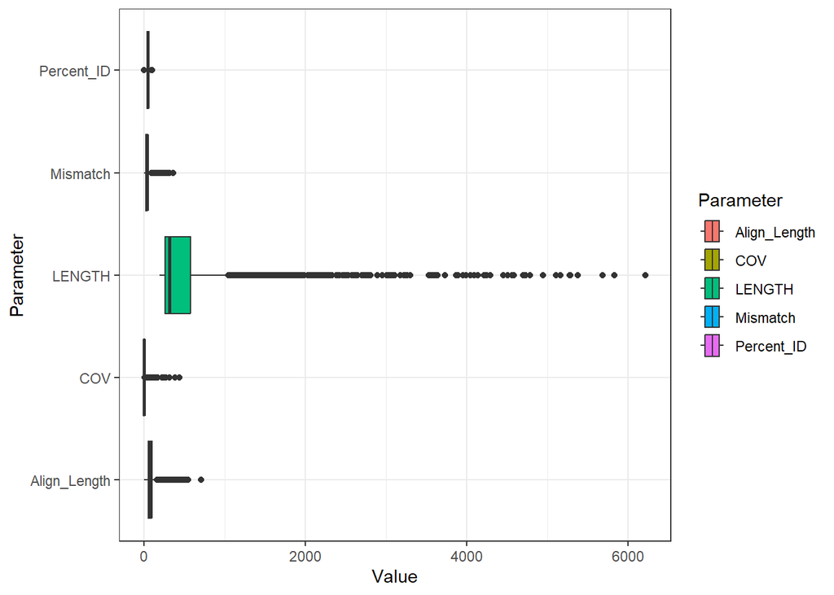

```r
new_df <- reduced_data %>% pivot_longer(cols = LENGTH:Mismatch, names_to = "Parameter", values_to = "Value")


new_df %>% ggplot(aes(x = Value, y = Parameter, fill = Parameter))+
  geom_boxplot()+
  theme_bw()
```

*___________________________________________________________________________________________________*

### **Conclusions**

The focus of this work was to analyze HTS data that was publicly available and to mine for viruses that were present in the samples, but had not been specifically investigated. For example, studies on gene expression to various environmental stimuli. It was a general expectation that viruses would be identified, but it was assumed that this would occur when analyzing a larger set of samples. Additionally, it was assumed that viruses would be detected, but they would likely be viruses that had previously been reported from the same region where the study was performed.

In this project, one HTS sample (paired read data) from a study done in China was analyzed, which produced several virus contigs with acceptable coverage, percent identity, and contig length. In particular, one virus (Rose cryptic virus 1 or RCV-1), was detected from the HTS sample analyzed. This was an entirely unexpected result, in the respect that RCV-1 had not previously been reported in the literature from China. Thankfully, RCV-1 has a commensalistic relationship with its host (in most known cases) and is therefore not of significant concern for the local rose growers. By extrapolation, this method is very useful in revealing viruses which are known to have a detrimental effect on their host, but have not been reported in a given region. This was a very useful method, and is something that can continually be pursued in the coming months-years. Not only is this method beneficial for the characterization of known viruses, but this may aid in the discovery of novel, previously undetected viruses.